# Bastos Lab – index

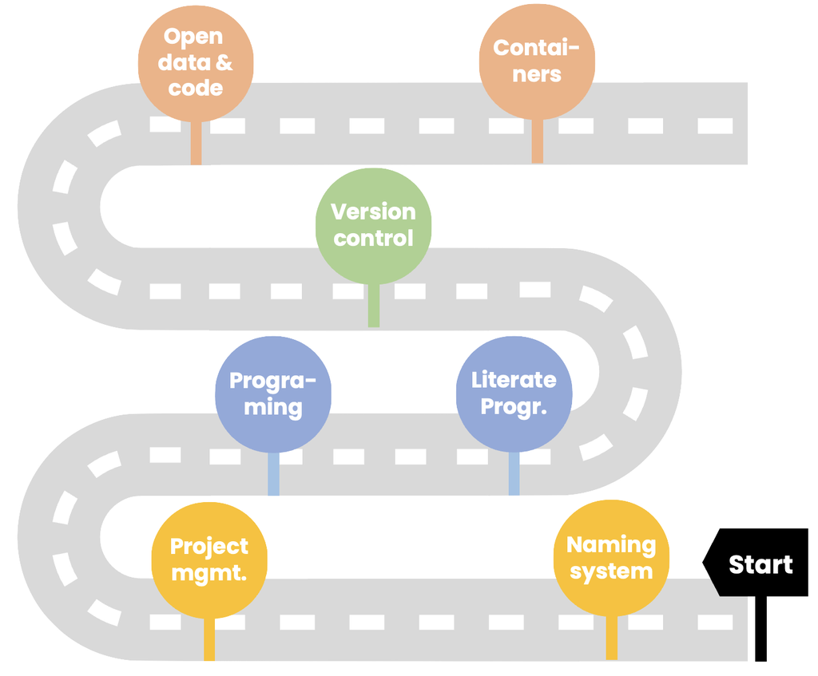

## From zero to hero: a researcher’s path through data science tools for reproducibility

Leonardo M. Bastos  
Assistant Professor  
Integrative Precision Agriculture

[figure not shown]

## What is reproducibility?

“Research is reproducible when others can reproduce the results of a scientific study given only the **original data, code, and documentation**”

This applies to:

- Other people reproducing your work
- Your future-self reproducing your past work

## Why bother with reproducible science?

- Tracks how and why of specific decisions and analysis
- Quickly modify analysis and figures
- Increased efficiency
- Rigor and transparency
- Increased citations (of paper, data, code)

## But is it really THAT important?

A [Nature survey](https://www.nature.com/articles/533452a) with ~1,600 researchers found that

- +70% of researchers have tried and failed to reproduce another scientist’s experiments
- +50% have failed to reproduce their own experiments
- Main causes: selective reporting, weak stats, code/data unavailability, etc.
- [2006 Duke University cancer research case](https://rss.onlinelibrary.wiley.com/doi/full/10.1111/j.1740-9713.2011.00505.x)

# My own path on reproducible science: barriers and solutions

# 🚧 Barrier #1: File naming and management

Starting my M.Sc., this is how my file management system looked like:

[figure not shown]

- Data, code, figures all mixed in same folder
- File names not very informative
- And this was just my first year! 😱
- Looks familiar?

# 🦸 Solution #1: principled file naming and project management

## Three principles of file naming

1. Machine readable

- contains key metadata, delimited with “-” and “_”

❌ sas cumulative flux 2 years.xlsx

✅ 2013-2014_N2O-cumulative.csv

- easy to search and filter
- easy to extract metadata

## Three principles of file naming

2. Human readable

- name provides info on content, slug concept

❌  
daily1.csv  
analysisyear1.qmd  
figure.png  
data2.csv  
anova2.qmd  
figure2test.png

✅  
2013-N2O-daily.csv  
2013-N2O-daily-anova.qmd  
2013-N2O-daily-plot.png 2014-N2O-daily.csv  
2014-N2O-daily-anova.qmd  
2014-N2O-daily-plot.png

Which set of files do you want at 3 am before a deadline?

## Three principles of file naming

3. Plays well with default ordering

- Start name with something numerical (date, time, experiment number, etc.)
- For dates, use **YYYY-MM-DD** format
- Left pad numbers with zero

❌  
N2O_daily_1-10-2013.csv  
10-23-2013_N2O_daily.csv  
2-15-2013_N2O_daily.csv

✅  
2013-01-10_N2O_daily.csv  
2013-02-15_N2O_daily.csv  
2013-10-23_N2O_daily.csv

## Principles of project management

From this:

[figure not shown]

To this:

[figure not shown]

## Principles of project management

[figure not shown]

- Create a minimum of three sub-folders: data, code, output

## Principles of project management

[figure not shown]

- Create a minimum of three sub-folders: data, code, output
- Keep data files in `data`, script files in `code`, and tables and figures in `output`
- In RStudio, use **RStudio Projects**!

# 🚧 Barrier #2: Proprietary, point-and-click software

Also during my M.Sc., I was using multiple **point-and-click**, **proprietary** software:

- Excel for data organization/manipulation
- SAS for stats
- SigmaPlot for plots
- ArcGIS for maps

**Warning**

**Proprietary** software and file extensions hamper reproducibility by imposing a paywall.

## Point-and-click is hard to document

- Point-and-click software is prone to human error, and normally humans are not good at **documenting** each step we do.
- Think about the last time you organized data in Excel. Do you remember each step you took when filtering or deleting cells, or when creating new columns? What was your decision-making process?
- Or maybe each step you took to create a complicated figure. How easy would it be for you to replicate it?

# 🦸 Solution #2: free programing languages

## Free and open-source software

Whenever possible and available, opt for **free, open source** software.

Instead of this:

- Excel
- SAS
- SigmaPlot
- ArcGIS

Use this:

- csv
- R/Python
- R/Python
- R/Python/QGIS

## Code is documentation

```r
df
```

```
  plot   n2o_ppm
1  101 0.7965260
2  102 1.1163717
3  103 1.7185601
4  104 2.7246234
5  105 0.6050458
```

```r
df %>%
  filter(n2o_ppm > 1) %>% # keeping only reasonable values
  mutate(n2o_ppb = n2o_ppm*1000) %>% #transforming ppm to ppb
  select(plot, n2o_ppb) # keeping only important columns
```

```
  plot  n2o_ppb
1  102 1116.372
2  103 1718.560
3  104 2724.623
```

**Tip**

Code is in itself documentation of each step you do. Adding comments with `#` make it even more understandable.

# 🚧 Barrier #3: Static programming and environment

## Static scripts with `.txt` or `.R`

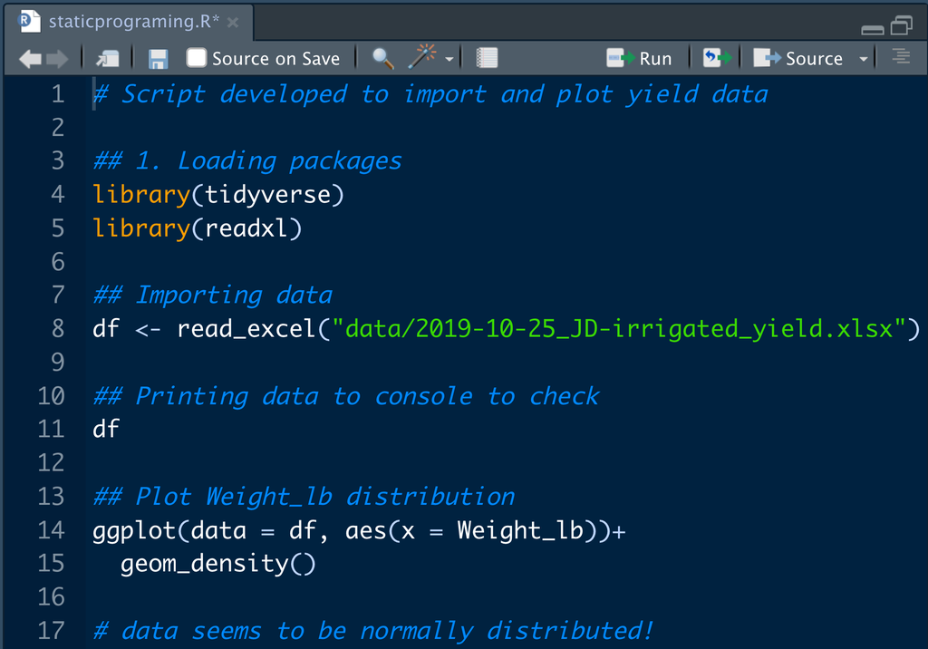

## Improvement: using an IDE

[figure not shown]

# 🦸 Solution #3: Literate programming (and IDEs)

## Literate progamming

- Mixes code, output, and narrative on the same file
- Examples:

[figure not shown]

# 🚧 Barrier #4: Keeping track of changes

## Can I go back in time?

**Situation**: you spent the whole week working on an analysis, only to find out it didn’t work as expected OR you got stuck with multiple bugs.

**Situation #2**: at some point your script had an important piece of code, but at the time you thought you didn’t need it anymore and deleted those lines.

Wouldn’t it be nice/useful/graduate-school-life-saving if you could simply go back in time and start fresh from your latest working version?

# 🦸 Solution #4: Version control

## Welcome in, version control

- Think of “track changes”, but on any file type
- Especially useful for **script files** (.Rmd, .qmd)
- As your code grows and develops, snapshots are saved allowing you to retrieve different versions
- This connects your current-self with your past-self (what were I thinking when I decided on doing this step?)
- Locally (in your own machine), use

[figure not shown]

# 🚧 Barrier #5: Reproducibility requires sharing

## git works locally

- **git** is powerful on its own, but it only acts locally
- It becomes really powerful when we can have its features working online
- Working with it online also happens to be perfect for **collaboration and sharing** 🤝

# 🦸 Solution #5: Open data and code

## Welcome in, GitHub

- **GitHub** is an online centralized platform that combines **git**, **collaborative tools**, and **cloud storage**, all free 💸
- You can choose if your projects hosted on GitHub (i.e., a repository) can be seen by **everyone (public)** or only by **you and invited collaborators (private)**

[figure not shown]

## GitHub demo

- I’ll show you next one of my GitHub repositories
- This repository was used to conduct the entire analytic flow of a manuscript among 2 collaborators
- Both collaborators had local versions on their computers, and GitHub served as the “merging” point

https://github.com/leombastos/BangPolder

# 🚧 Barrier #6: What if software versions change?

## Things change

- Computer operating systems get updated
- R gets updated
- RStudio gets updated
- R packages get updated

Even if we are working off of the same GitHub repository, our local software versions may differ, which can cause discrepancies and issues that may **impact reproducibility**.

# 🦸 Solution #6: Containerization

## Containerizing projects

- To avoid discrepancies of software versions, we can use **containers**
- **Containers** keep track of all software versions in a project, and ship that project with those default versions
- This ensures the project is reproducible not only for **collaborators**, but also **your future self**
- One example of container software is

[figure not shown]

# In a nutshell

## 🚧 ⏩ 🦸 Reproducible science is about…

- Using sensible **file names**
- Organizing files in sensible **sub-folders**
- Using **free programming language software**
- Using **literate programming** tools
- Using **version control locally**
- Using **distributed version control** to collaborate and share data and code
- Using **containers**
- Others (custom functions, iteration, code peer-review, etc.)

## Personal marketing

- This entire presentation was made with **quarto**, and its source code is available on my GitHub
- You can find more info on my lab’s website (also made with **quarto**): [Bastos Lab](https://leombastos.github.io/bastoslab/)

[figure not shown]

- You can also find stats programming teaching material (video+code) on my [website](https://leombastos.github.io/bastoslab/teaching/teaching.html)
- Wish to learn and apply these concepts to your own research?
- **Data Science and Stats Prog Applied to Ag (this course!)**, Spring 2025
- **Thanks!** 🙏 💻